# Tugas : ANN (due date: 26 Mei 2023 09.00)

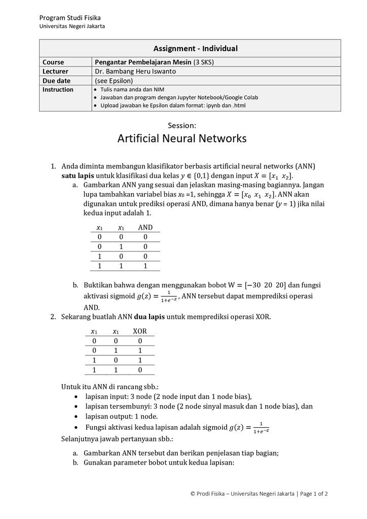

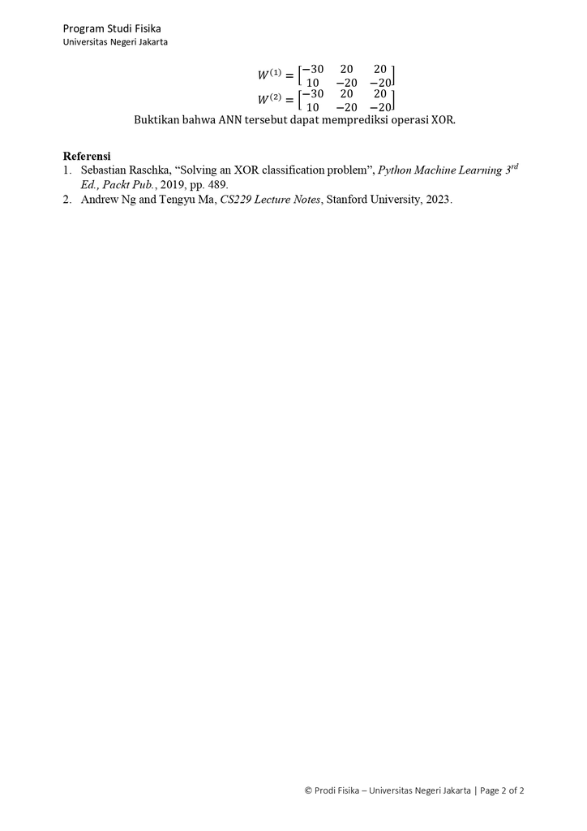

- Nama : Muhammad Rizky Anugrah
- NIM : 1306620089
- Kelas : Fisika - B
- Angkatan : 2020
- Dosen Pengampu : Dr.rer.nat. Bambang Heru Iswanto

## IMPORT

```python
import numpy as np
import matplotlib.pyplot as plt
import warnings
warnings.filterwarnings('ignore')
```

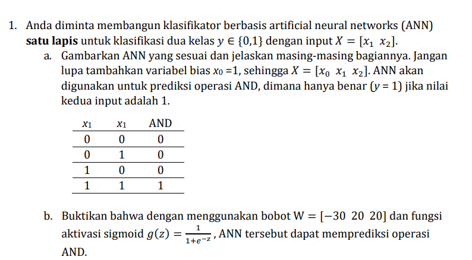

## 1.a

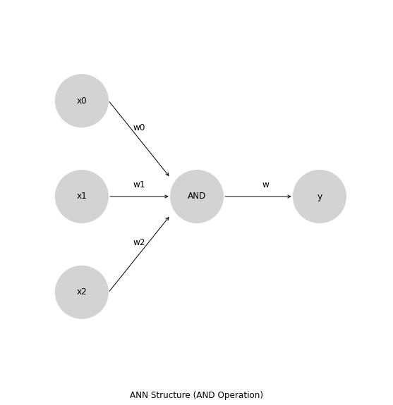

```python
import matplotlib.pyplot as plt

# Membuat gambar dan sumbu
fig, ax = plt.subplots(figsize=(10, 10))

# Mengatur batasan sumbu
ax.set_xlim(0, 1)
ax.set_ylim(0, 1)

# Menggambar neuron input
ax.add_patch(plt.Circle((0.2, 0.75), 0.07, fc='lightgray'))
ax.text(0.2, 0.75, 'x0', fontsize=12, ha='center', va='center')

ax.add_patch(plt.Circle((0.2, 0.5), 0.07, fc='lightgray'))
ax.text(0.2, 0.5, 'x1', fontsize=12, ha='center', va='center')

ax.add_patch(plt.Circle((0.2, 0.25), 0.07, fc='lightgray'))
ax.text(0.2, 0.25, 'x2', fontsize=12, ha='center', va='center')

# Menggambar neuron AND
ax.add_patch(plt.Circle((0.5, 0.5), 0.07, fc='lightgray'))
ax.text(0.5, 0.5, 'AND', fontsize=12, ha='center', va='center')

# Menggambar panah koneksi
ax.annotate("", xy=(0.43, 0.55), xytext=(0.27, 0.75), arrowprops=dict(arrowstyle="->"))
ax.annotate("", xy=(0.43, 0.5), xytext=(0.27, 0.5), arrowprops=dict(arrowstyle="->"))
ax.annotate("", xy=(0.43, 0.45), xytext=(0.27, 0.25), arrowprops=dict(arrowstyle="->"))
ax.annotate("", xy=(0.75, 0.5), xytext=(0.57, 0.5), arrowprops=dict(arrowstyle="->"))

# Menambahkan bobot pada panah koneksi
ax.text(0.35, 0.68, 'w0', fontsize=12, ha='center', va='center')
ax.text(0.35, 0.53, 'w1', fontsize=12, ha='center', va='center')
ax.text(0.35, 0.38, 'w2', fontsize=12, ha='center', va='center')
ax.text(0.68, 0.53, 'w', fontsize=12, ha='center', va='center')

# Menggambar neuron output
ax.add_patch(plt.Circle((0.82, 0.5), 0.07, fc='lightgray'))
ax.text(0.82, 0.5, 'y', fontsize=12, ha='center', va='center')

# Mengatur label dan judul
ax.set_xticks([])
ax.set_yticks([])
ax.set_frame_on(False)
ax.set_aspect('equal')
plt.xlabel("ANN Structure (AND Operation)", fontsize=12)

# Menampilkan gambar
plt.show()
```

1. x0, x1, x2: Merupakan neuron input. Dalam jaringan saraf tiruan, neuron input adalah titik awal dari informasi yang masuk ke dalam jaringan. Pada plottingan ini, terdapat tiga neuron input yang direpresentasikan oleh lingkaran dengan label x0, x1, dan x2. Masing-masing neuron input memiliki nilai yang dapat digunakan sebagai input untuk menjalankan operasi logika AND. x0: Merupakan neuron input dengan nilai bias. Dalam jaringan saraf tiruan, neuron input adalah titik awal dari informasi yang masuk ke dalam jaringan. Selain itu, bias diberikan pada setiap neuron input untuk mempengaruhi output mereka. Dalam plottingan ini, x0 direpresentasikan sebagai lingkaran dengan label x0 dan memiliki nilai bias sebesar 1.
2. w0, w1, w2: Merupakan bobot yang menghubungkan neuron input (x0, x1, x2) dengan neuron AND. Bobot (weight) adalah faktor yang mengatur seberapa besar pengaruh setiap neuron input terhadap neuron yang terhubung dengannya. Pada plottingan ini, terdapat tiga panah koneksi yang menghubungkan neuron input dengan neuron AND, dan setiap panah koneksi memiliki label bobot yang ditunjukkan oleh w0, w1, dan w2.
3. AND: Merupakan neuron yang menjalankan operasi logika AND terhadap input yang diterimanya. Neuron ini menggabungkan input dari neuron input (x0, x1, x2) menggunakan bobot (w0, w1, w2) untuk menghasilkan output yang merupakan hasil dari operasi logika AND. Pada plottingan ini, neuron AND direpresentasikan oleh lingkaran dengan label "AND".
4. w: Merupakan bobot yang menghubungkan neuron AND dengan neuron output (y). Bobot ini mengatur seberapa besar pengaruh neuron AND terhadap neuron output. Pada plottingan ini, terdapat satu panah koneksi yang menghubungkan neuron AND dengan neuron output, dan panah koneksi tersebut memiliki label bobot yang ditunjukkan oleh w.
5. y: Merupakan neuron output yang menghasilkan output dari operasi logika AND. Neuron ini menerima input dari neuron AND menggunakan bobot w, dan kemudian menghasilkan output berdasarkan operasi logika AND yang dilakukan. Pada plottingan ini, neuron output direpresentasikan oleh lingkaran dengan label y.

## 1.b

```python
import numpy as np

# Definisikan fungsi aktivasi sigmoid
def sigmoid(z):
    return 1 / (1 + np.exp(-z))

# Definisikan input, target, dan bobot
X = np.array([[0, 0], [0, 1], [1, 0], [1, 1]])  # Input X
y = np.array([0, 0, 0, 1])  # Target y
W = np.array([-30, 20, 20], dtype=np.float64)  # Bobot W (ubah tipe data menjadi float64)

# Tambahkan kolom x0 = 1 pada input X
X = np.insert(X, 0, 1, axis=1)

# Inisialisasi hyperparameter
learning_rate = 0.1
epochs = 1000

# Training single-layer perceptron
for epoch in range(epochs):
    # Hitung output dan error
    output = sigmoid(np.dot(X, W))
    error = y - output

    # Update bobot menggunakan aturan delta rule
    delta = learning_rate * np.dot(X.T, error)
    W = W + delta  # ubah W += delta menjadi W = W + delta

# Evaluasi klasifikasi
predictions = np.round(output)
accuracy = np.mean(predictions == y)

# Menampilkan hasil klasifikasi XOR
print("x1\tx2\tAND")
for i in range(len(X)):
    x1, x2 = X[i][1], X[i][2]
    AND = predictions[i]
    AND = int(AND)
    print(f"{x1}\t{x2}\t{AND}")

accuracy_percent = accuracy * 100
print("Accuracy:", f"{accuracy_percent}%")
```

```
x1	x2	AND
0	0	0
0	1	0
1	0	0
1	1	1
Accuracy: 100.0%
```

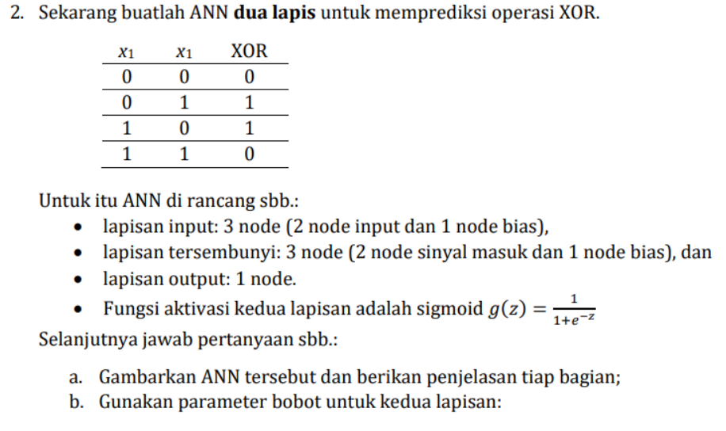

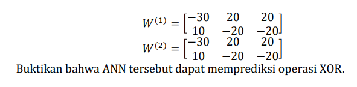

## 2.a

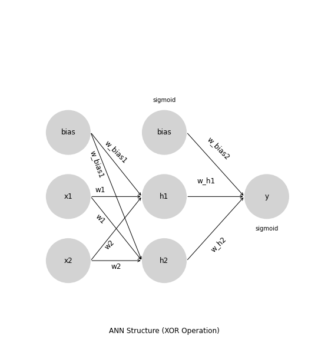

```python
import matplotlib.pyplot as plt
import matplotlib.patches as patches
from matplotlib.patches import FancyArrowPatch

# Membuat gambar dan sumbu
fig, ax = plt.subplots(figsize=(10, 10))

# Menggambar neuron input layer
ax.add_patch(patches.Circle((0.2, 0.6), 0.07, fc='lightgray'))
ax.text(0.2, 0.6, 'bias', fontsize=12, ha='center', va='center')

ax.add_patch(patches.Circle((0.2, 0.4), 0.07, fc='lightgray'))
ax.text(0.2, 0.4, 'x1', fontsize=12, ha='center', va='center')

ax.add_patch(patches.Circle((0.2, 0.2), 0.07, fc='lightgray'))
ax.text(0.2, 0.2, 'x2', fontsize=12, ha='center', va='center')

# Menggambar neuron hidden layer
ax.add_patch(patches.Circle((0.5, 0.6), 0.07, fc='lightgray'))
ax.text(0.5, 0.6, 'bias', fontsize=12, ha='center', va='center')

ax.add_patch(patches.Circle((0.5, 0.4), 0.07, fc='lightgray'))
ax.text(0.5, 0.4, 'h1', fontsize=12, ha='center', va='center')

ax.add_patch(patches.Circle((0.5, 0.2), 0.07, fc='lightgray'))
ax.text(0.5, 0.2, 'h2', fontsize=12, ha='center', va='center')

# Menggambar neuron output layer
ax.add_patch(patches.Circle((0.82, 0.4), 0.07, fc='lightgray'))
ax.text(0.82, 0.4, 'y', fontsize=12, ha='center', va='center')

# Menggambar panah koneksi
ax.annotate("", xy=(0.43, 0.4), xytext=(0.27, 0.6), arrowprops=dict(arrowstyle="->"))
ax.annotate("", xy=(0.43, 0.2), xytext=(0.27, 0.6), arrowprops=dict(arrowstyle="->"))
ax.annotate("", xy=(0.43, 0.4), xytext=(0.27, 0.4), arrowprops=dict(arrowstyle="->"))
ax.annotate("", xy=(0.43, 0.2), xytext=(0.27, 0.4), arrowprops=dict(arrowstyle="->"))
ax.annotate("", xy=(0.43, 0.4), xytext=(0.27, 0.2), arrowprops=dict(arrowstyle="->"))
ax.annotate("", xy=(0.43, 0.2), xytext=(0.27, 0.2), arrowprops=dict(arrowstyle="->"))
ax.annotate("", xy=(0.75, 0.4), xytext=(0.57, 0.6), arrowprops=dict(arrowstyle="->"))
ax.annotate("", xy=(0.75, 0.4), xytext=(0.57, 0.4), arrowprops=dict(arrowstyle="->"))
ax.annotate("", xy=(0.75, 0.4), xytext=(0.57, 0.2), arrowprops=dict(arrowstyle="->"))

# Menggambar label bobot
ax.text(0.35, 0.54, 'w_bias1', fontsize=12, ha='center', va='center', rotation=315)
ax.text(0.29, 0.50, 'w_bias1', fontsize=12, ha='center', va='center', rotation=290)
ax.text(0.30, 0.42, 'w1', fontsize=12, ha='center', va='center')
ax.text(0.30, 0.33, 'w1', fontsize=12, ha='center', va='center', rotation=315)
ax.text(0.33, 0.25, 'w2', fontsize=12, ha='center', va='center', rotation=45)
ax.text(0.35, 0.18, 'w2', fontsize=12, ha='center', va='center')

ax.text(0.67, 0.55, 'w_bias2', fontsize=12, ha='center', va='center', rotation=315)
ax.text(0.63, 0.45, 'w_h1', fontsize=12, ha='center', va='center')
ax.text(0.67, 0.25, 'w_h2', fontsize=12, ha='center', va='center', rotation=45)

# Menggambar label fungsi aktivasi
ax.text(0.5, 0.7, 'sigmoid', fontsize=10, ha='center', va='center')
ax.text(0.82, 0.3, 'sigmoid', fontsize=10, ha='center', va='center')

# Mengatur label dan judul
ax.set_xlim(0, 1)
ax.set_ylim(0, 1)
ax.set_xticks([])
ax.set_yticks([])
ax.set_frame_on(False)
ax.set_aspect('equal')
plt.xlabel("ANN Structure (XOR Operation)", fontsize=12)

# Menampilkan gambar
plt.show()
```

1. Input Layer:

Neuron bias: Representasi dari bias dalam jaringan saraf tiruan (Artificial Neural Network/ANN). Bias biasanya digunakan untuk menambahkan kekuatan atau pengurangan pada aktivasi neuron. Neuron x1: Representasi dari input pertama. Neuron ini menerima nilai input pertama dari dataset atau masukan yang diberikan. Neuron x2: Representasi dari input kedua. Neuron ini menerima nilai input kedua dari dataset atau masukan yang diberikan.

1. Hidden Layer:

1. Bobot (Weights):

w_bias1: Bobot yang menghubungkan bias pada input layer dengan neuron h1 di hidden layer. Bobot ini menentukan pengaruh bias terhadap aktivasi neuron h1. w_bias2: Bobot yang menghubungkan bias pada hidden layer dengan neuron output y. Bobot ini menentukan pengaruh bias terhadap aktivasi neuron output y. w1: Bobot yang menghubungkan input x1 dengan neuron h1 di hidden layer. Bobot ini menentukan pengaruh input x1 terhadap aktivasi neuron h1. w2: Bobot yang menghubungkan input x2 dengan neuron h1 di hidden layer. Bobot ini menentukan pengaruh input x2 terhadap aktivasi neuron h1. w_h1: Bobot yang menghubungkan neuron h1 dengan neuron output y. Bobot ini menentukan pengaruh aktivasi neuron h1 terhadap aktivasi neuron output y. w_h2: Bobot yang menghubungkan neuron h2 dengan neuron output y. Bobot ini menentukan pengaruh aktivasi neuron h2 terhadap aktivasi neuron output y.

1. Output Layer:

1. Fungsi Aktivasi:

Sigmoid: Merupakan fungsi aktivasi yang digunakan pada neuron di hidden layer dan output layer. Fungsi sigmoid mengubah nilai input menjadi nilai output yang berada dalam rentang antara 0 dan 1. Fungsi sigmoid digunakan untuk memperkenalkan non-linearitas pada jaringan saraf tiruan.

## 2.b

```python
import numpy as np

def sigmoid(z):
    return 1 / (1 + np.exp(-z))

def predict(X, weights):
    # Forward propagation
    hidden_layer_input = np.dot(X, weights[0].T)
    hidden_layer_output = sigmoid(hidden_layer_input)
    hidden_layer_output_with_bias = np.insert(hidden_layer_output, 0, 1, axis=1)  # Menambahkan bias
    output_layer_input = np.dot(hidden_layer_output_with_bias, weights[1].T)
    output_layer_output = sigmoid(output_layer_input)
    return output_layer_output

# Bobot
w1 = np.array([[-30, 20, 20],
               [10, -20, -20]])
w2 = np.array([[-30, 20, 20],
               [10, -20, -20]])

# Input (XOR truth table dengan x0 = 1)
x0 = np.ones((4, 1))
x1 = np.array([[0], [0], [1], [1]])
x2 = np.array([[0], [1], [0], [1]])

# Menggabungkan x0, x1, x2 menjadi matriks X
X = np.hstack((x0, x1, x2))

# Memperoleh prediksi
predictions = predict(X, [w1, w2])

predictions = np.round(predictions)

# Menampilkan hasil prediksi dan akurasi
correct_predictions = 0
print("x1\tx2\tXOR")
for i, prediction in enumerate(predictions):
    x1, x2 = X[i, 1], X[i, 2]
    x1 = int(x1)
    x2 = int(x2)
    xor_result = 1 if prediction.any() >= 0.5 else 0
    print(f'{x1}\t{x2}\t{xor_result}')
    if xor_result == np.logical_xor(x1, x2):
        correct_predictions += 1

accuracy = correct_predictions / len(predictions) * 100
print(f'Accuracy: {accuracy}%')
```

```
x1	x2	XOR
0	0	0
0	1	1
1	0	1
1	1	0
Accuracy: 100.0%
```

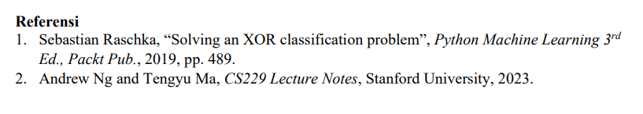